Known feature/bug of RNotebooks - Notebooks are executed in the same directory as the file but we want to set the working directory to the root directory.

```r
# Correct RNotebook working directory bug
knitr::opts_knit$set(root.dir = normalizePath("C:/Users/cfull/OneDrive/Desktop/suq21-5210-w5-pa4-5"))
```

```r
# Course: 5210 Communicating Data
# Purpose: Participation Assignment #3
# Date: July 17, 2021
```

# 1 Load Packages

```r
# Load packages

# The tidyverse package contains ggplot2, dplyr, and several other packages we will use
library(tidyverse)
# The gridExtra package contains grid.arrange function used to combine plots in the same window
library(gridExtra)
# The janitor package contains tidyverse functions for cross-tables
library(janitor)
# The knitr package contains some table formating functions
library(knitr)

# The GGally package contains a custom correlation plot we will use
library(GGally)
# The scales package contains scale_y_continues for plot label formatting
library(scales)
# ggannotate
library(ggannotate)
```

# 2 Load Data

```r
king_sales <- read_csv("data/qp1_data.csv")
```

# 3 Base EDA Step 1 - Uni-variate Non-graphical Data

```r
# View the data
head(king_sales, 10)
```

```
## # A tibble: 10 x 13
##      price bedrooms bathrooms sqft_living sqft_lot floors waterfront  view grade
##      <dbl>    <dbl>     <dbl>       <dbl>    <dbl>  <dbl>      <dbl> <dbl> <dbl>
##  1  221900        3      1           1180     5650      1          0     0     7
##  2  538000        3      2.25        2570     7242      2          0     0     7
##  3  180000        2      1            770    10000      1          0     0     6
##  4  604000        4      3           1960     5000      1          0     0     7
##  5  510000        3      2           1680     8080      1          0     0     8
##  6 1230000        4      4.5         5420   101930      1          0     0    11
##  7  257500        3      2.25        1715     6819      2          0     0     7
##  8  291850        3      1.5         1060     9711      1          0     0     7
##  9  229500        3      1           1780     7470      1          0     0     7
## 10  323000        3      2.5         1890     6560      2          0     0     7
## # ... with 4 more variables: condition <dbl>, yr_built <dbl>,
## #   yr_renovated <dbl>, zip_code <dbl>
```

**Comments**

- Data appears tidy:
  - Each column is a variable and the data is the same type
  - There are 13 variables
  - There are no duplicative variables
  - Each row is an observation for the sale of a specific home

## 3.1 Data Structure

```r
# convert bedrooms, waterfront and view variables from numerical to factor
names <- c('waterfront', 'view', 'condition')
king_sales[,names] <- lapply(king_sales[,names], factor)

# Check the structure of the data
str(king_sales)
```

```
## spec_tbl_df [21,613 x 13] (S3: spec_tbl_df/tbl_df/tbl/data.frame)
##  $ price       : num [1:21613] 221900 538000 180000 604000 510000 ...
##  $ bedrooms    : num [1:21613] 3 3 2 4 3 4 3 3 3 3 ...
##  $ bathrooms   : num [1:21613] 1 2.25 1 3 2 4.5 2.25 1.5 1 2.5 ...
##  $ sqft_living : num [1:21613] 1180 2570 770 1960 1680 ...
##  $ sqft_lot    : num [1:21613] 5650 7242 10000 5000 8080 ...
##  $ floors      : num [1:21613] 1 2 1 1 1 1 2 1 1 2 ...
##  $ waterfront  : Factor w/ 2 levels "0","1": 1 1 1 1 1 1 1 1 1 1 ...
##  $ view        : Factor w/ 5 levels "0","1","2","3",..: 1 1 1 1 1 1 1 1 1 1 ...
##  $ grade       : num [1:21613] 7 7 6 7 8 11 7 7 7 7 ...
##  $ condition   : Factor w/ 5 levels "1","2","3","4",..: 3 3 3 5 3 3 3 3 3 3 ...
##  $ yr_built    : num [1:21613] 1955 1951 1933 1965 1987 ...
##  $ yr_renovated: num [1:21613] 0 1991 0 0 0 ...
##  $ zip_code    : num [1:21613] 98178 98125 98028 98136 98074 ...
##  - attr(*, "spec")=
##   .. cols(
##   ..   price = col_double(),
##   ..   bedrooms = col_double(),
##   ..   bathrooms = col_double(),
##   ..   sqft_living = col_double(),
##   ..   sqft_lot = col_double(),
##   ..   floors = col_double(),
##   ..   waterfront = col_double(),
##   ..   view = col_double(),
##   ..   grade = col_double(),
##   ..   condition = col_double(),
##   ..   yr_built = col_double(),
##   ..   yr_renovated = col_double(),
##   ..   zip_code = col_double()
##   .. )
```

**Comments**

## 3.2 Descriptive statistics

```r
# Summary statistics of data
summary(king_sales)
```

```
##      price            bedrooms        bathrooms      sqft_living
##  Min.   :  75000   Min.   : 0.000   Min.   :0.000   Min.   :  290
##  1st Qu.: 321950   1st Qu.: 3.000   1st Qu.:1.750   1st Qu.: 1427
##  Median : 450000   Median : 3.000   Median :2.250   Median : 1910
##  Mean   : 540182   Mean   : 3.371   Mean   :2.115   Mean   : 2080
##  3rd Qu.: 645000   3rd Qu.: 4.000   3rd Qu.:2.500   3rd Qu.: 2550
##  Max.   :7700000   Max.   :33.000   Max.   :8.000   Max.   :13540
##     sqft_lot           floors      waterfront view          grade
##  Min.   :    520   Min.   :1.000   0:21450    0:19489   Min.   : 1.000
##  1st Qu.:   5040   1st Qu.:1.000   1:  163    1:  332   1st Qu.: 7.000
##  Median :   7618   Median :1.500              2:  963   Median : 7.000
##  Mean   :  15107   Mean   :1.494              3:  510   Mean   : 7.657
##  3rd Qu.:  10688   3rd Qu.:2.000              4:  319   3rd Qu.: 8.000
##  Max.   :1651359   Max.   :3.500                        Max.   :13.000
##  condition    yr_built     yr_renovated       zip_code
##  1:   30   Min.   :1900   Min.   :   0.0   Min.   :98001
##  2:  172   1st Qu.:1951   1st Qu.:   0.0   1st Qu.:98033
##  3:14031   Median :1975   Median :   0.0   Median :98065
##  4: 5679   Mean   :1971   Mean   :  84.4   Mean   :98078
##  5: 1701   3rd Qu.:1997   3rd Qu.:   0.0   3rd Qu.:98118
##            Max.   :2015   Max.   :2015.0   Max.   :98199
```

**Comments**

- Data appears balanced across number of bedrooms
- Price, sqft_living, and sqft_lot variables appear to be right skewed (asymmetrical)
  - mean != median and mean >> median
  - in these cases, we’ll use the median
  - yr_renovated is 84.4 for mean, 2015 for max but 0 for min, 1st Qu., median, and 3rd Qu. (that is alerting) - what could be going on here?
- Bedrooms, bathrooms and floors variables all appear to be symmetrical
  - mean = median
- For price, is 7700000 an outlier?
  - significantly higher than 3rd Qu. 645000
- For bedrooms, is 33 an outlier?
  - significantly higher than 3rd Qu. 4
- For bathrooms, is 8 an outlier?
  - higher than 3rd Qu. 2.5
- For sqft_living, is 13540 an outlier?
  - significantly higher than 3rd Qu. 2550
- For sqft_lot, is 1651359 an outlier?
  - significantly higher than 3rd Qu. 10688

**Questions**

- yr_renovated is 84.4 for mean, 2015 for max but 0 for min, 1st Qu., median, and 3rd Qu. What could be going on here?
- Is there really a specific home with 33 bedrooms and 8 bathrooms or could this be an anomaly?

# 4 Base EDA Step 2: Uni-variate Graphical

- In this step, we will examine each variable individually

## 4.1 Categorical/Factor Variables:

- Take a look at all categorical variables together

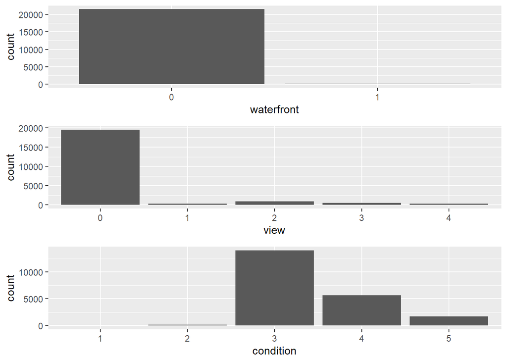

```r
# Only use bar graphs
grid.arrange(

# waterfront
ggplot(data = king_sales, mapping = aes(x = waterfront)) +
  geom_bar(),

# view
ggplot(data = king_sales, mapping = aes(x = view)) +
  geom_bar(),

# condition
ggplot(data = king_sales, mapping = aes(x = condition)) +
  geom_bar(),


ncol = 1)
```

**Comments**

- Most homes sold are not waterfront locations and have little to no view. On the other hand the conditions when sold were mostly 3 and 4 (mediocre) for King County.

## 4.2 Quantitative Variables

### 4.2.1 Price

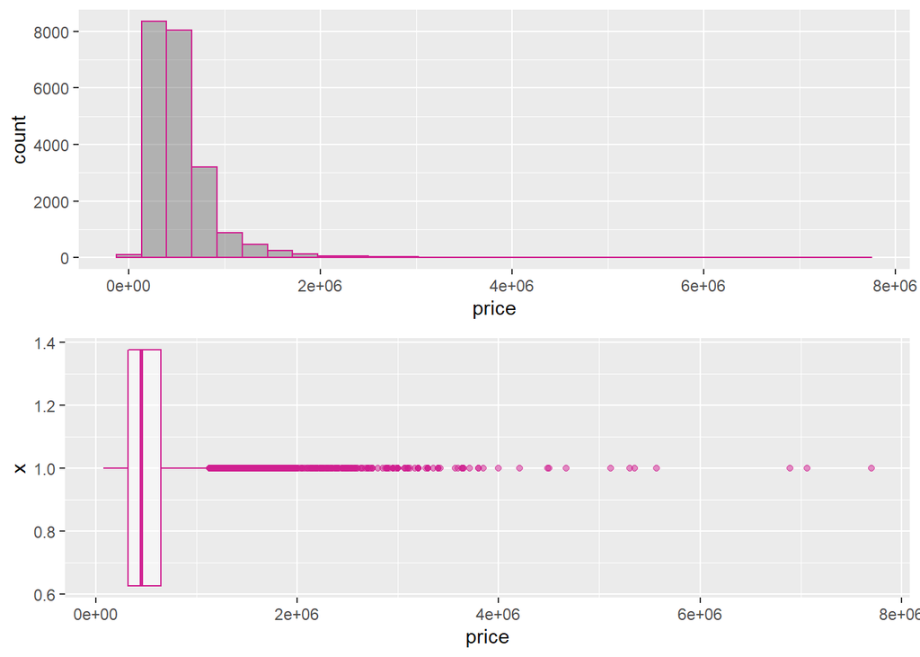

```r
# Use grid.arrange() to display multiple graphs together
grid.arrange(

# Create a histogram of price
ggplot(data = king_sales, mapping = aes(x = price)) +
  geom_histogram(color = "violetred", alpha = 0.4, adjust = 2),

# Add a boxplot
ggplot(data = king_sales, mapping = aes(x = 1)) +
  geom_boxplot(mapping = aes(y = price), color = "violetred", alpha = 0.5) +
  coord_flip(), # flip to make the x-axis the same

# Set the number of columns
ncol = 1)
```

**Comments**

- Confirm the price is still slightly right skewed as suspected
  - There were a number of outliers, which heavily skewed the mean.
  - Median is best to use for the analysis of this variable
- Most homes sold lie within the $300,000 to $600,000 price range

### 4.2.2 Bedrooms

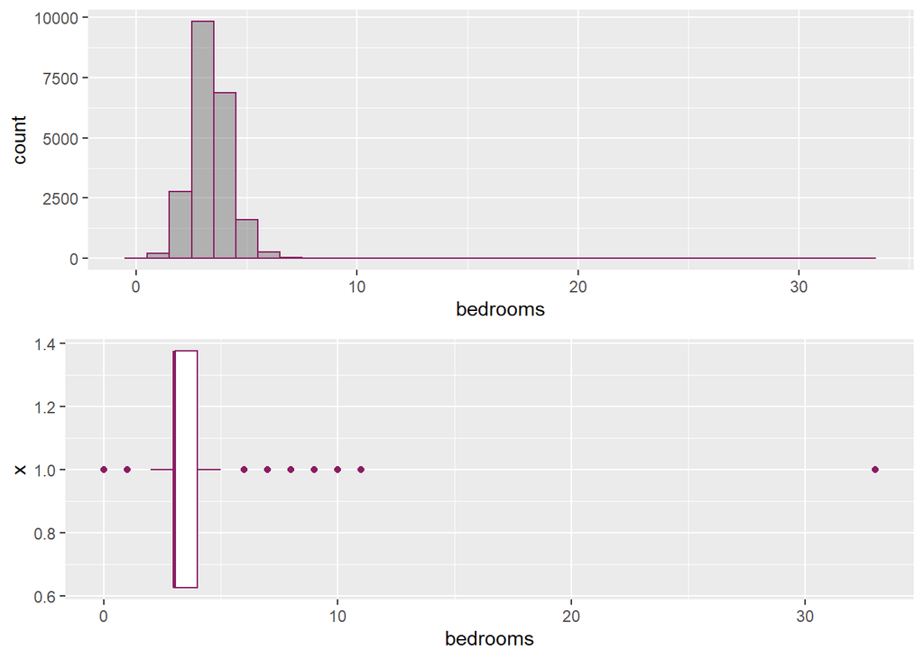

```r
# Use grid.arrange() to display multiple graphs together
grid.arrange(

# Create a histogram of price
ggplot(data = king_sales, mapping = aes(x = bedrooms)) +
  geom_histogram(binwidth = 1, color = "maroon4", alpha = 0.4, adjust = 2),

# Add a boxplot
ggplot(data = king_sales, mapping = aes(x = 1)) +
  geom_boxplot(mapping = aes(y = bedrooms), color = "maroon4") +
  coord_flip(), # flip to make the x-axis the same

# Set the number of columns
ncol = 1)
```

**Comments**

- Confirm that after eliminating outliers, the bedrooms variable is more normally distributed
  - Okay to use the mean
- The majority of homes sold in King Country were commonly 3 and 4 bedroom homes.

**Questins**

- Are the number of bedrooms and sqft_living correlated?
- Are the bedrooms and sqft_living relative to price?

### 4.2.3 Bathrooms

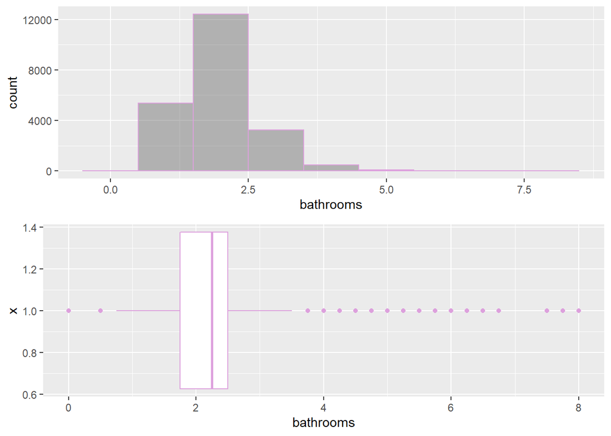

```r
# Use grid.arrange() to display multiple graphs together
grid.arrange(

# Create a histogram of price
ggplot(data = king_sales, mapping = aes(x = bathrooms)) +
  geom_histogram(binwidth = 1, color = "plum", alpha = 0.4, adjust = 2),

# Add a boxplot
ggplot(data = king_sales, mapping = aes(x = 1)) +
  geom_boxplot(mapping = aes(y = bathrooms), color = "plum") +
  coord_flip(), # flip to make the x-axis the same

# Set the number of columns
ncol = 1)
```

**Comments**

- Even after eliminating outliers, bathrooms variable is still slightly right skewed but not a severe
  - Best to use the median
- Majority of homes sold had 2 bathrooms.

### 4.2.4 Square Footage (Living)

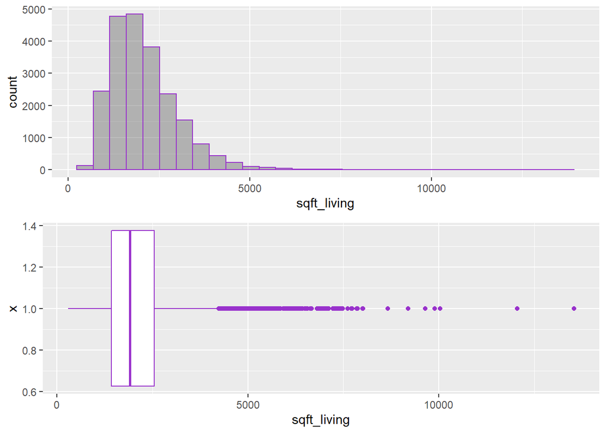

```r
# Use grid.arrange() to display multiple graphs together
grid.arrange(

# Create a histogram of sqft_living
ggplot(data = king_sales, mapping = aes(x = sqft_living)) +
  geom_histogram(color = "darkorchid", alpha = 0.4, adjust = 2),


# Add a boxplot
ggplot(data = king_sales, mapping = aes(x = 1)) +
  geom_boxplot(mapping = aes(y = sqft_living), color = "darkorchid") +
  coord_flip(), # flip to make the x-axis the same

# Set the number of columns
ncol = 1)
```

**Comments**

- Confirm that sqft_living is normally distributed with a slight right skew
  - Okay to use the mean
- Majority of homes sold are within 1500 sqft to 2500 sqft, with multiple outliers
  - The outliers are skewing the mean so median is best to use for the analysis of this variable

### 4.2.5 Square Footage (Lot)

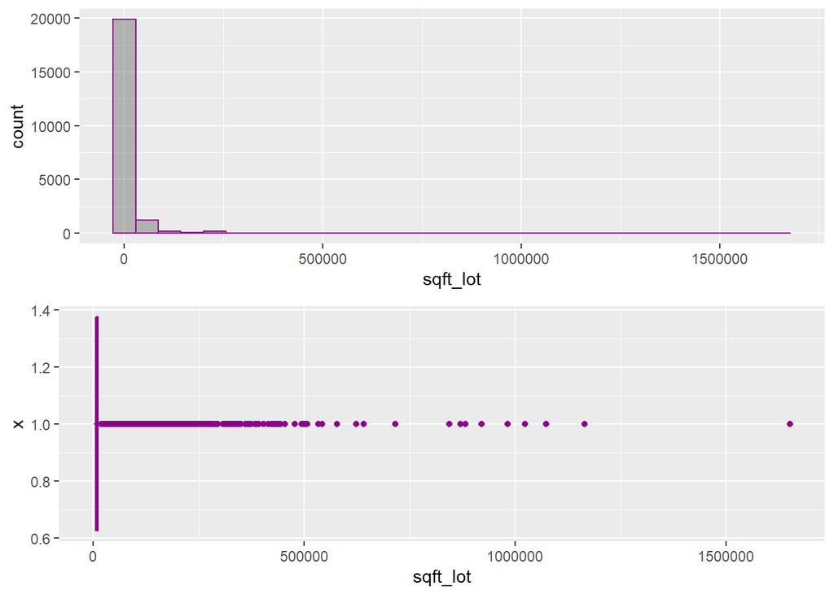

```r
# Use grid.arrange() to display multiple graphs together
grid.arrange(

# Create a histogram of sqft_lot
ggplot(data = king_sales, mapping = aes(x = sqft_lot)) +
  geom_histogram(color = "magenta4", alpha = 0.4, adjust = 2),


# Add a boxplot
ggplot(data = king_sales, mapping = aes(x = 1)) +
  geom_boxplot(mapping = aes(y = sqft_lot), color = "magenta4") +
  coord_flip(), # flip to make the x-axis the same

# Set the number of columns
ncol = 1)
```

**Comments**

- Confirms that sqft_lot is asymmetrical and right skew as suspected
  - Since data is skewed, we will use the median instead of mean

**Question**

- Does the sqft_lot have less of an effect on price than sqft_living?

### 4.2.6 Year Built

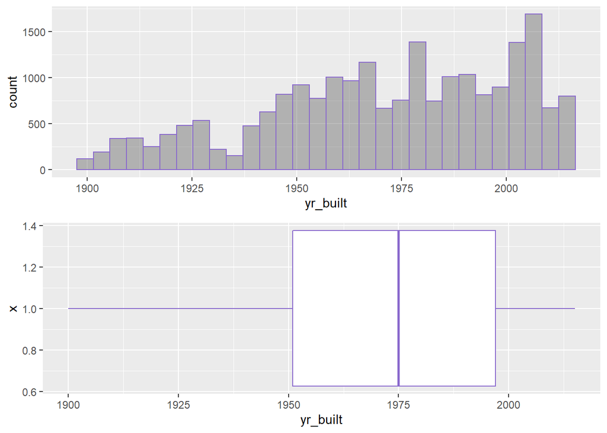

```r
# Use grid.arrange() to display multiple graphs together
grid.arrange(

# Create a histogram of yr_built
ggplot(data = king_sales, mapping = aes(x = yr_built)) +
  geom_histogram(color = "mediumpurple3", alpha = 0.4, adjust = 2),


# Add a boxplot
ggplot(data = king_sales, mapping = aes(x = 1)) +
  geom_boxplot(mapping = aes(y = yr_built), color = "mediumpurple3") +
  coord_flip(), # flip to make the x-axis the same

# Set the number of columns
ncol = 1)
```

**Comments**

**Questions**

- Would eliminating years > 2000 improve or worsen the model?

# 5 Base EDA Step 3: Multi-variate Non-graphical

## 5.1 Categorical

```r
# Contingnecy/Cross tabulation for multiple variables

king_sales %>%
  tabyl(bedrooms, grade) %>%
  adorn_totals(where = c("row", "col")) %>%
  kable()
```

| bedrooms | 1 | 10 | 11 | 12 | 13 | 3 | 4 | 5 | 6 | 7 | 8 | 9 | Total |
| --- | --- | --- | --- | --- | --- | --- | --- | --- | --- | --- | --- | --- | --- |
| 0 | 1 | 0 | 0 | 1 | 0 | 0 | 2 | 0 | 0 | 6 | 3 | 0 | 13 |
| 1 | 0 | 1 | 0 | 0 | 0 | 3 | 12 | 37 | 78 | 52 | 14 | 2 | 199 |
| 2 | 0 | 21 | 3 | 2 | 0 | 0 | 14 | 114 | 824 | 1205 | 499 | 78 | 2760 |
| 3 | 0 | 296 | 56 | 9 | 1 | 0 | 1 | 62 | 854 | 4917 | 2796 | 832 | 9824 |
| 4 | 0 | 615 | 239 | 49 | 3 | 0 | 0 | 21 | 233 | 2177 | 2194 | 1351 | 6882 |
| 5 | 0 | 173 | 83 | 24 | 6 | 0 | 0 | 5 | 41 | 501 | 455 | 313 | 1601 |
| 6 | 0 | 22 | 13 | 3 | 3 | 0 | 0 | 3 | 7 | 98 | 90 | 33 | 272 |
| 7 | 0 | 5 | 4 | 1 | 0 | 0 | 0 | 0 | 1 | 11 | 12 | 4 | 38 |
| 8 | 0 | 1 | 0 | 1 | 0 | 0 | 0 | 0 | 0 | 6 | 4 | 1 | 13 |
| 9 | 0 | 0 | 1 | 0 | 0 | 0 | 0 | 0 | 0 | 4 | 1 | 0 | 6 |
| 10 | 0 | 0 | 0 | 0 | 0 | 0 | 0 | 0 | 0 | 2 | 0 | 1 | 3 |
| 11 | 0 | 0 | 0 | 0 | 0 | 0 | 0 | 0 | 0 | 1 | 0 | 0 | 1 |
| 33 | 0 | 0 | 0 | 0 | 0 | 0 | 0 | 0 | 0 | 1 | 0 | 0 | 1 |
| Total | 1 | 1134 | 399 | 90 | 13 | 3 | 29 | 242 | 2038 | 8981 | 6068 | 2615 | 21613 |

```r
# Proportion contingency/cross tabulation for bedrooms and waterfront

king_sales %>%
  tabyl(bedrooms, grade) %>%
  adorn_totals(where = c("row", "col")) %>%
  adorn_percentages(denominator = "all") %>% # create proportions
  adorn_rounding(2) %>%  # round decimal two places
  kable()
```

| bedrooms | 1 | 10 | 11 | 12 | 13 | 3 | 4 | 5 | 6 | 7 | 8 | 9 | Total |
| --- | --- | --- | --- | --- | --- | --- | --- | --- | --- | --- | --- | --- | --- |
| 0 | 0 | 0.00 | 0.00 | 0 | 0 | 0 | 0 | 0.00 | 0.00 | 0.00 | 0.00 | 0.00 | 0.00 |
| 1 | 0 | 0.00 | 0.00 | 0 | 0 | 0 | 0 | 0.00 | 0.00 | 0.00 | 0.00 | 0.00 | 0.01 |
| 2 | 0 | 0.00 | 0.00 | 0 | 0 | 0 | 0 | 0.01 | 0.04 | 0.06 | 0.02 | 0.00 | 0.13 |
| 3 | 0 | 0.01 | 0.00 | 0 | 0 | 0 | 0 | 0.00 | 0.04 | 0.23 | 0.13 | 0.04 | 0.45 |
| 4 | 0 | 0.03 | 0.01 | 0 | 0 | 0 | 0 | 0.00 | 0.01 | 0.10 | 0.10 | 0.06 | 0.32 |
| 5 | 0 | 0.01 | 0.00 | 0 | 0 | 0 | 0 | 0.00 | 0.00 | 0.02 | 0.02 | 0.01 | 0.07 |
| 6 | 0 | 0.00 | 0.00 | 0 | 0 | 0 | 0 | 0.00 | 0.00 | 0.00 | 0.00 | 0.00 | 0.01 |
| 7 | 0 | 0.00 | 0.00 | 0 | 0 | 0 | 0 | 0.00 | 0.00 | 0.00 | 0.00 | 0.00 | 0.00 |
| 8 | 0 | 0.00 | 0.00 | 0 | 0 | 0 | 0 | 0.00 | 0.00 | 0.00 | 0.00 | 0.00 | 0.00 |
| 9 | 0 | 0.00 | 0.00 | 0 | 0 | 0 | 0 | 0.00 | 0.00 | 0.00 | 0.00 | 0.00 | 0.00 |
| 10 | 0 | 0.00 | 0.00 | 0 | 0 | 0 | 0 | 0.00 | 0.00 | 0.00 | 0.00 | 0.00 | 0.00 |
| 11 | 0 | 0.00 | 0.00 | 0 | 0 | 0 | 0 | 0.00 | 0.00 | 0.00 | 0.00 | 0.00 | 0.00 |
| 33 | 0 | 0.00 | 0.00 | 0 | 0 | 0 | 0 | 0.00 | 0.00 | 0.00 | 0.00 | 0.00 | 0.00 |
| Total | 0 | 0.05 | 0.02 | 0 | 0 | 0 | 0 | 0.01 | 0.09 | 0.42 | 0.28 | 0.12 | 1.00 |

```r
# Proportional contingency/cross tabulation for bedrooms and sqft_living
king_sales %>%
  tabyl(bedrooms, waterfront) %>%
  adorn_totals(where = c("row", "col")) %>%
  adorn_percentages(denominator = "all") %>% # create proportions
  adorn_rounding(4) %>%  # round decimal two places
  kable()
```

| bedrooms | 0 | 1 | Total |
| --- | --- | --- | --- |
| 0 | 0.0006 | 0.0000 | 0.0006 |
| 1 | 0.0090 | 0.0002 | 0.0092 |
| 2 | 0.1263 | 0.0014 | 0.1277 |
| 3 | 0.4516 | 0.0030 | 0.4545 |
| 4 | 0.3166 | 0.0019 | 0.3184 |
| 5 | 0.0732 | 0.0009 | 0.0741 |
| 6 | 0.0124 | 0.0002 | 0.0126 |
| 7 | 0.0018 | 0.0000 | 0.0018 |
| 8 | 0.0006 | 0.0000 | 0.0006 |
| 9 | 0.0003 | 0.0000 | 0.0003 |
| 10 | 0.0001 | 0.0000 | 0.0001 |
| 11 | 0.0000 | 0.0000 | 0.0000 |
| 33 | 0.0000 | 0.0000 | 0.0000 |
| Total | 0.9925 | 0.0075 | 1.0000 |

**Comments**

- Confirms the number of bedrooms on waterfront or view are not consistent across
  - Most sales fall under those that are not located on waterfront
  - We’ll need to model these
  - We shouldn’t analyze houses with 0, 7, 8, 9, 10, 11, and 33 bedrooms. Those have low counts

**Questions**

- Need to verify price as it relates to number of bathrooms and sqft_living

## 5.2 Quantitative

```r
# Correlation table

king_sales %>%
  select(is.numeric) %>%
  cor() %>%
  round(2) %>%
  kable(align = 'c', caption = "Numeric Variables Correlation Table")
```

Numeric Variables Correlation Table

|  | price | bedrooms | bathrooms | sqft_living | sqft_lot | floors | grade | yr_built | yr_renovated | zip_code |
| --- | --- | --- | --- | --- | --- | --- | --- | --- | --- | --- |
| price | 1.00 | 0.31 | 0.53 | 0.70 | 0.09 | 0.26 | 0.67 | 0.05 | 0.13 | -0.05 |
| bedrooms | 0.31 | 1.00 | 0.52 | 0.58 | 0.03 | 0.18 | 0.36 | 0.15 | 0.02 | -0.15 |
| bathrooms | 0.53 | 0.52 | 1.00 | 0.75 | 0.09 | 0.50 | 0.66 | 0.51 | 0.05 | -0.20 |
| sqft_living | 0.70 | 0.58 | 0.75 | 1.00 | 0.17 | 0.35 | 0.76 | 0.32 | 0.06 | -0.20 |
| sqft_lot | 0.09 | 0.03 | 0.09 | 0.17 | 1.00 | -0.01 | 0.11 | 0.05 | 0.01 | -0.13 |
| floors | 0.26 | 0.18 | 0.50 | 0.35 | -0.01 | 1.00 | 0.46 | 0.49 | 0.01 | -0.06 |
| grade | 0.67 | 0.36 | 0.66 | 0.76 | 0.11 | 0.46 | 1.00 | 0.45 | 0.01 | -0.18 |
| yr_built | 0.05 | 0.15 | 0.51 | 0.32 | 0.05 | 0.49 | 0.45 | 1.00 | -0.22 | -0.35 |
| yr_renovated | 0.13 | 0.02 | 0.05 | 0.06 | 0.01 | 0.01 | 0.01 | -0.22 | 1.00 | 0.06 |
| zip_code | -0.05 | -0.15 | -0.20 | -0.20 | -0.13 | -0.06 | -0.18 | -0.35 | 0.06 | 1.00 |

**Comments**

**Questions**

- Does positive correlation indicate causation?
- Does price increase with sqft_living and grade?

# 6 Base EDA Step 4: Multi-variate Graphical

## 6.1 Step 4.1: Categorical

- Distribution or summary of quantitative and categorical variable, bar graphs, and multiple boxplots

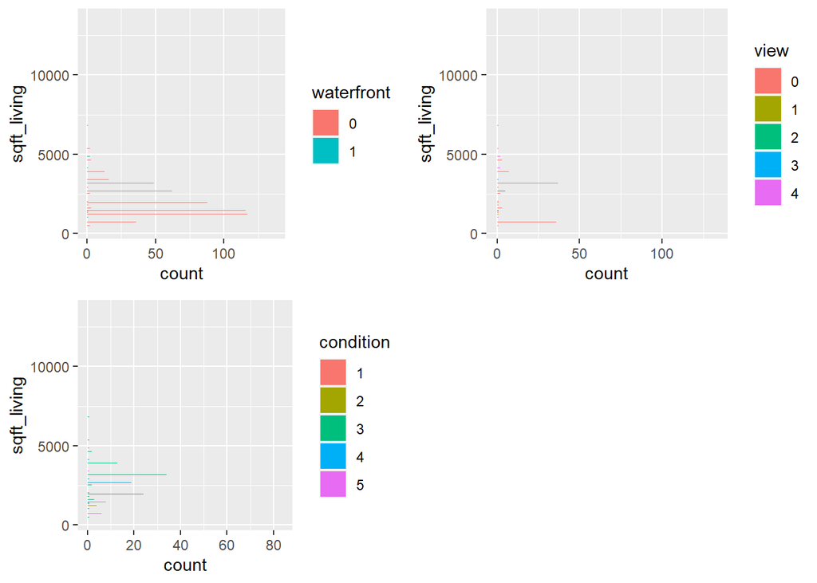

```r
# Use grid.arrange() so we can see all uni-variate bar graphs together

grid.arrange(

  king_sales %>%
    ggplot(mapping = aes(x = sqft_living, fill = waterfront)) +
    geom_bar(position = "dodge") +
    coord_flip(),

  king_sales %>%
    ggplot(mapping = aes(x = sqft_living, fill = view)) +
    geom_bar(position = "dodge") +
    coord_flip(),

  king_sales %>%
    ggplot(mapping = aes(x = sqft_living, fill = condition)) +
    geom_bar(position = "dodge") +
    coord_flip(),

  ncol = 2
)
```

**Comments**

- Homes with no waterfront location nor view are more prominent

**Questions**

- Have more homes sold without waterfront or views in King County because of price?

## 6.2 Step 4.1: Categorical

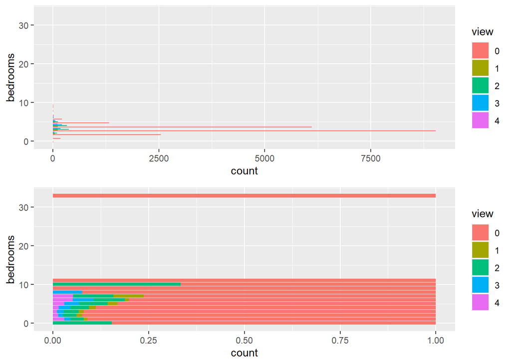

```r
# More detail on bedrooms and view

grid.arrange(
  # Cluster of counts
  king_sales %>%
    ggplot(mapping = aes(x = bedrooms, fill = view)) +
    geom_bar(position = "dodge") +
    coord_flip(),

  # Proportion of counts
  king_sales %>%
    ggplot(mapping = aes(x = bedrooms, fill = view)) +
    geom_bar(position = "fill") +
    coord_flip(),

ncol = 1)
```

## 6.3 Step 4.2: Quantitative

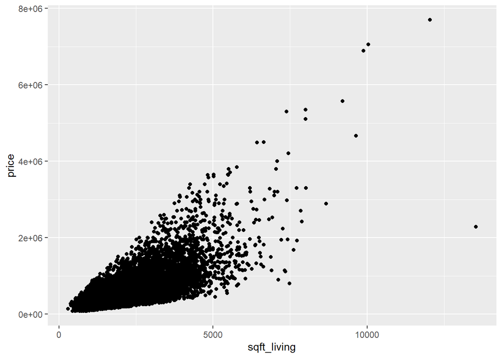

```r
# Scatterplots using grid.arrange() to see all quantitave variables of interest together

king_sales %>%
  ggplot(mapping = aes(x = sqft_living, y = price)) +
  geom_point()
```

**Comments**

- This is pattern is quite clustered from 290 sqft to 5000 sqft. Then it disperses.

## 6.4 Step 4.3: Categorical and Quantitative

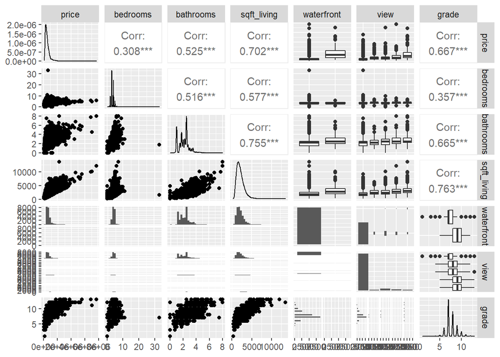

```r
# Use ggpairs from the GGally package
king_sales %>%
  select(-c(sqft_lot, yr_renovated)) %>%
  ggpairs(columns = c(1:4, 6:8))
```

**Questions**

- Look closer at the following variable relationships:
  - sqft_living and bathrooms
  - sqft_living and grade
  - sqft_living and bedrooms
  - bathrooms and grade
  - price and grade

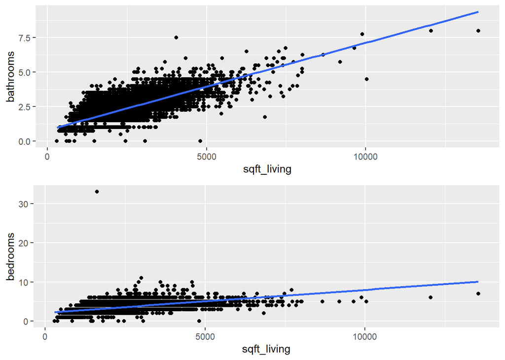

```r
# follow up on correlation graphs

grid.arrange(

  # sqft_living and bathrooms
  king_sales %>%
    ggplot(mapping = aes(x = sqft_living, y = bathrooms)) +
    geom_point() +
    geom_smooth(method = "lm", se = FALSE),

  # sqft_living and bedrooms
  king_sales %>%
    ggplot(mapping = aes(x = sqft_living, y = bedrooms)) +
    geom_point() +
    geom_smooth(method = "lm", se = FALSE),

  ncol = 1)
```

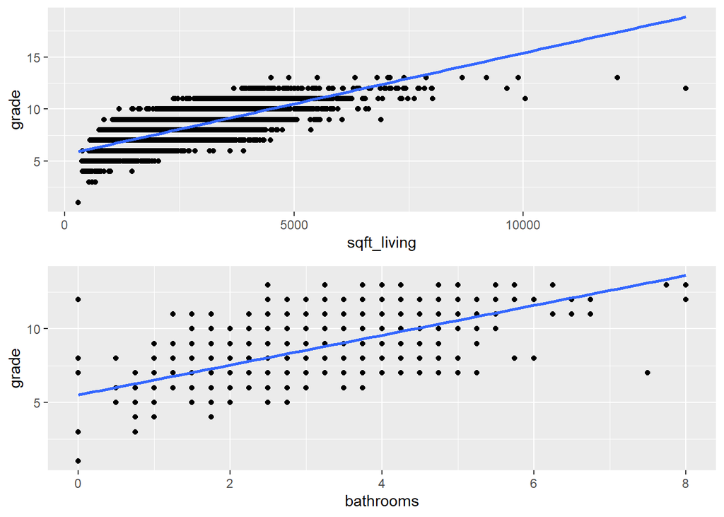

```r
grid.arrange(

  # sqft_living and grade
  king_sales %>%
    ggplot(mapping = aes(x = sqft_living, y = grade)) +
    geom_point() +
    geom_smooth(method = "lm", se = FALSE),

  # bathrooms and grade
  king_sales %>%
    ggplot(mapping = aes(x = bathrooms, y = grade)) +
    geom_point() +
    geom_smooth(method = "lm", se = FALSE),


  ncol = 1)
```

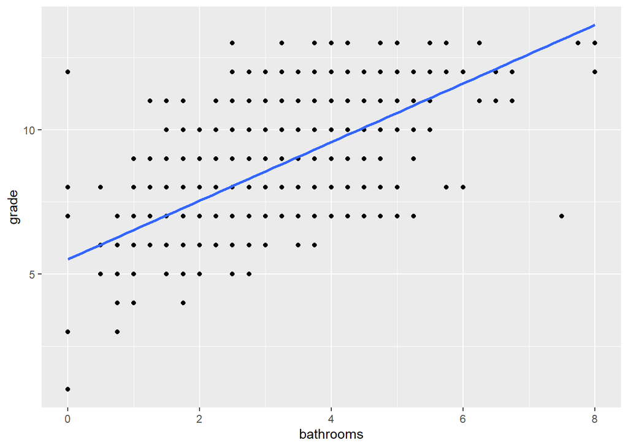

```r
grid.arrange(

  # price and grade
  king_sales %>%
    ggplot(mapping = aes(x = bathrooms, y = grade)) +
    geom_point() +
    geom_smooth(method = "lm", se = FALSE),


ncol = 1)
```

**Comments**

# 7 Detailed EDA - Questions Raised in Base EDA

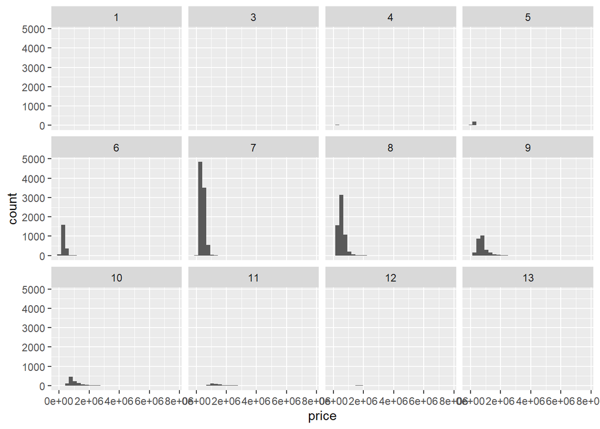

```r
# facet histogram - price and grade
king_sales %>%
  ggplot(mapping = aes(x = price)) +
  geom_histogram() +
  facet_wrap( ~ grade)
```

**Comments**

- The pattern holds

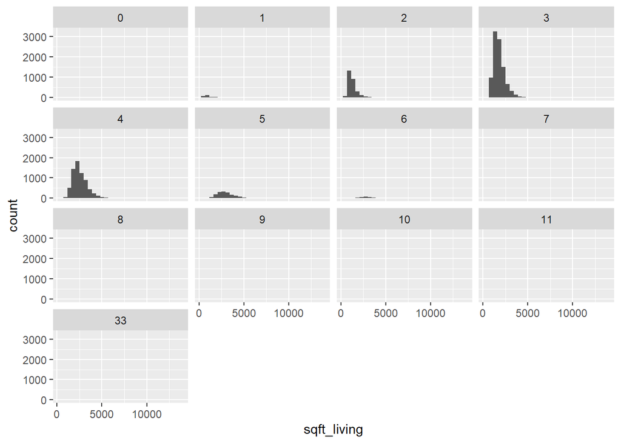

```r
# facet histograms - sqft_living and bedrooms
king_sales %>%
  ggplot(mapping = aes(x = sqft_living)) +
  geom_histogram() +
  facet_wrap( ~ bedrooms)
```

**Comments**

- The pattern holds. Let’s explore this relationship further.

## 7.3 Does price differ across sqft_living and grade?

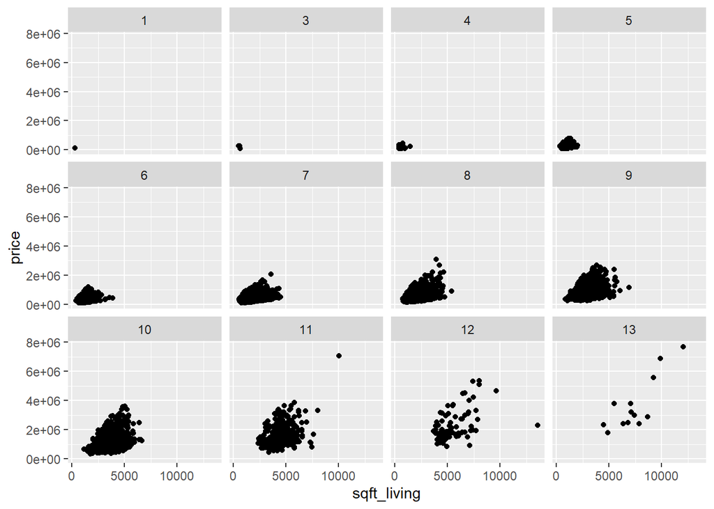

```r
# facet histograms - price
king_sales %>%
  ggplot(mapping = aes(x = sqft_living, y = price)) +
  geom_jitter(width = 0.5) +
  facet_wrap( ~ grade)
```

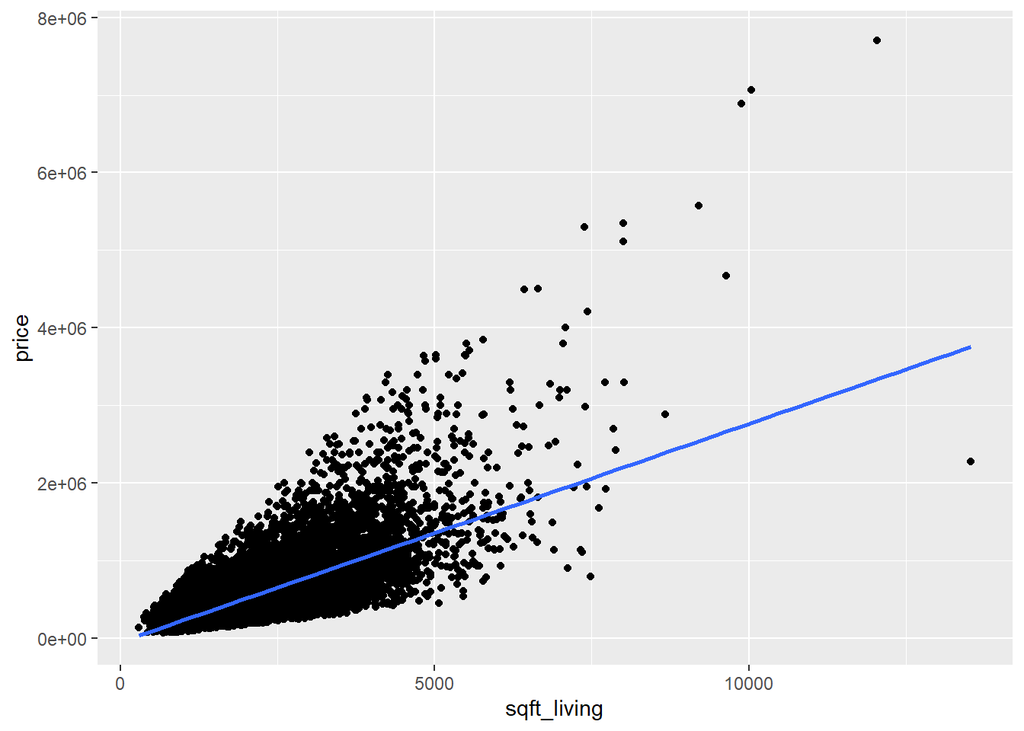

```r
king_sales %>%
  ggplot(mapping = aes(x = sqft_living, y = price)) +
  geom_jitter(width = 0.5) +
  geom_smooth(method = "lm", se = FALSE)
```

# 8 Summary

- Most houses sold in King County do not come with waterfront locations or good views at that.
- The King County housing market appears to be influenced by features including the number of square footage of living space, the grade quality of a home, as well as the number of bathrooms included.
- Pricing appears to be consistent across sqft_living and grade.